# Group 88 - UDL Assignment 2: Part A

## Image Generation with beta-VAE and VQ-VAE + PixelCNN Prior

## Team Details

| Student Name | Student ID | Contribution | Signature / Initial |
| --- | --- | --- | --- |
| Lalit Tyagi | 2024ac05569 | 100% | LT |
| Sreejith M V | 2024AD05421 | 100% | SV |
| Ashwini N | 2024ad05029 | 100% | AN |
| Ashok Pyaram | 2024ad05197 | 100% | AP |
| Gopikannan G | 2024ac05790 | 100% | GG |

**Dataset:** CIFAR-10 (pixels scaled to [0, 1])  
**Framework:** PyTorch

## Part A: (β-)VAE and VQ-VAE with PixelCNN Prior

#### Environment Setup & Data Pipeline

```python
import os
import math
import time
import numpy as np
import matplotlib.pyplot as plt
from tqdm import tqdm

import torch
import torch.nn as nn
import torch.nn.functional as F
from torch.utils.data import DataLoader
from torchvision import datasets, transforms
import torchvision.utils as vutils
from google.colab import drive


# --- Setup Device ---
device = torch.device("cuda" if torch.cuda.is_available() else "cpu")
print(f"Using device: {device}")

# 1. Force unmount any zombie/broken connections
try:
    drive.flush_and_unmount()
    print("Unmounted previous broken sessions successfully.")
except:
    pass

# 2. Mount cleanly to the required root path
drive.mount('/content/drive', force_remount=True)

# --- Define a dedicated folder in your Google Drive for datasets ---
# This ensures it persists across sessions so you don't have to re-download it.
drive_data_path = '/content/drive/MyDrive/datasets'
os.makedirs(drive_data_path, exist_ok=True)
saved_samples_path = '/content/drive/MyDrive/saved_samples'
os.makedirs(saved_samples_path, exist_ok=True)

# --- Pure-PyTorch Data Loading Pipeline ---
def pil_to_tensor_without_numpy(image):
    image = image.convert('RGB')
    pixels = torch.frombuffer(bytearray(image.tobytes()), dtype=torch.uint8)
    return pixels.view(image.height, image.width, 3).permute(2, 0, 1).float().div(255.0)

transform = transforms.Lambda(pil_to_tensor_without_numpy)

train_dataset = datasets.CIFAR10(root=drive_data_path, train=True, download=True, transform=transform)
test_dataset = datasets.CIFAR10(root=drive_data_path, train=False, download=True, transform=transform)

train_loader = DataLoader(train_dataset, batch_size=128, shuffle=True, num_workers=0)
test_loader = DataLoader(test_dataset, batch_size=128, shuffle=False, num_workers=0)
```

```
Using device: cuda
Unmounted previous broken sessions successfully.
```

**Discussion: IO Optimization and Data Representation**

- Avoiding Tensor Locks: Standard torchvision.transforms.ToTensor() internally relies on NumPy arrays for bridge construction. In a strict multi-GPU cloud instance, asynchronous workers passing NumPy arrays via shared memory frequently trigger interlocking segmentation faults.
- Pure-Tensor Pipeline: By extracting raw bytes out of the PIL container directly into a torch.frombuffer signature, data stays within pure C-space memory boundaries before being cast into a tensor.
- Normalization Constraints: Scaling inputs to $[0, 1]$ directly aligns with the Sigmoid activations used in both the standard VAE and VQ-VAE decoders, establishing a fixed range for standard Mean Squared Error (MSE) computations.

#### On-GPU Mathematical Metric Engines

```python
def calculate_batch_mse(img1, img2):
    """Calculates the raw Mean Squared Error across all pixels in a batch."""
    return torch.mean((img1 - img2) ** 2).item()

def calculate_colour_frechet_proxy(real_imgs, gen_imgs, eps=1e-12):
    def features(images):
        if images.dim() == 4:
            return F.adaptive_avg_pool2d(images, (8, 8)).flatten(1)
        return images.flatten(1)

    def covariance(values):
        centered = values - values.mean(dim=0, keepdim=True)
        return centered.T @ centered / max(values.size(0) - 1, 1)

    real_features, gen_features = features(real_imgs).float(), features(gen_imgs).float()
    mu_real, mu_gen = real_features.mean(dim=0), gen_features.mean(dim=0)
    sigma_real, sigma_gen = covariance(real_features), covariance(gen_features)

    identity = torch.eye(sigma_real.size(0), device=real_imgs.device, dtype=real_imgs.dtype)
    eigenvalues, eigenvectors = torch.linalg.eigh(sigma_real + eps * identity)
    sqrt_real = (eigenvectors * eigenvalues.clamp_min(0).sqrt()) @ eigenvectors.T
    middle = sqrt_real @ (sigma_gen + eps * identity) @ sqrt_real
    trace_sqrt = torch.linalg.eigvalsh(middle).clamp_min(0).sqrt().sum()

    fid_score = (mu_real - mu_gen).pow(2).sum() + torch.trace(sigma_real + sigma_gen) - 2 * trace_sqrt
    return fid_score.clamp_min(0).item()
```

**Discussion: Mathematical Evaluation Infrastructure**

- PSNR Stability & Averaging: Rather than averaging pre-calculated batch PSNR values directly (which creates a mathematically invalid arithmetic mean of logarithms), this updated framework aggregates raw Mean Squared Error (MSE) linearly over the dataset, calculating the logarithm only at the final boundary condition. This strictly respects Jensen's Inequality.
- Pure-Tensor Fréchet Score: Standard FID setups download a large pretrained InceptionV3 network and move data back to the CPU via SciPy. This script implements an efficient Color Fréchet Proxy that bypasses third-party weights.
- Linear Algebra Optimization: By extracting channel-wise activation distributions directly on the GPU using torch.linalg.eigh (Hermitian matrix eigendecomposition), we capture statistical variance and distribution shifts across color spaces without any CPU context-switching overhead.

#### Continuous Latent Beta-VAE Architecture

```python
class BetaVAE(nn.Module):
    def __init__(self, latent_dim=128):
        super(BetaVAE, self).__init__()
        self.encoder = nn.Sequential(
            nn.Conv2d(3, 32, 4, stride=2, padding=1),
            nn.BatchNorm2d(32),
            nn.ReLU(),
            nn.Conv2d(32, 64, 4, stride=2, padding=1),
            nn.BatchNorm2d(64),
            nn.ReLU(),
            nn.Conv2d(64, 128, 4, stride=2, padding=1),
            nn.BatchNorm2d(128),
            nn.ReLU(),
            nn.Flatten()
        )
        self.fc_mu = nn.Linear(128 * 4 * 4, latent_dim)
        self.fc_logvar = nn.Linear(128 * 4 * 4, latent_dim)

        self.decoder_input = nn.Linear(latent_dim, 128 * 4 * 4)
        self.decoder = nn.Sequential(
            nn.ConvTranspose2d(128, 64, 4, stride=2, padding=1),
            nn.BatchNorm2d(64),
            nn.ReLU(),
            nn.ConvTranspose2d(64, 32, 4, stride=2, padding=1),
            nn.BatchNorm2d(32),
            nn.ReLU(),
            nn.ConvTranspose2d(32, 3, 4, stride=2, padding=1),
            nn.Sigmoid()
        )

    def encode(self, x):
        h = self.encoder(x)
        return self.fc_mu(h), self.fc_logvar(h)

    def reparameterize(self, mu, logvar):
        std = torch.exp(0.5 * logvar)
        eps = torch.randn_like(std)
        return mu + eps * std

    def decode(self, z):
        h = self.decoder_input(z).view(-1, 128, 4, 4)
        return self.decoder(h)

    def forward(self, x):
        mu, logvar = self.encode(x)
        z = self.reparameterize(mu, logvar)
        return self.decode(z), mu, logvar
```

**Discussion: Reparameterization and Topology**

- Stochastic Backpropagation: Neural networks cannot backpropagate gradients through random sampling operations. The reparameterize method resolves this by shifting the stochastic element out of the computational graph. It expresses the latent sample as $z = \mu + \sigma \odot \epsilon$, where $\epsilon \sim \mathcal{N}(0, I)$.
- Log-Variance Stability: Rather than directly predicting the standard deviation $\sigma$, which requires strict positive enforcement, the network predicts $\log(\sigma^2)$. This allows the linear layer outputs to span across the entire real number line without numerical instability.
- Spatial Compression: The encoder steadily reduces spatial dimensions from a $32\times32$ image down to a dense $4\times4$ representation across 128 channels. This forces the model to distill spatial correlations into high-level abstract features before mapping them to the bottleneck.

#### Beta-VAE Hyperparameter Optimization Loop

```python
def train_beta_vae(beta, epochs=20):
    # Start tracking the time for this specific beta configuration
    start_time = time.time()

    model = BetaVAE().to(device)
    optimizer = torch.optim.Adam(model.parameters(), lr=1e-3)
    history_psnr = []

    for epoch in range(epochs):
        model.train()
        total_loss, total_mse = 0, 0
        for x, _ in train_loader:
            x = x.to(device)
            recon_x, mu, logvar = model(x)

            recon_loss = F.mse_loss(recon_x, x, reduction='sum')
            kld_loss = -0.5 * torch.sum(1 + logvar - mu.pow(2) - logvar.exp())
            loss = recon_loss + beta * kld_loss

            optimizer.zero_grad()
            loss.backward()
            optimizer.step()

            total_loss += loss.item()
            total_mse += calculate_batch_mse(x, recon_x)

        # Log-of-Means Application over Epoch Batches
        avg_mse = total_mse / len(train_loader)
        avg_mse = max(avg_mse, 1e-8)
        avg_psnr = 20 * math.log10(1.0 / math.sqrt(avg_mse))
        history_psnr.append(avg_psnr)
        print(f"Beta={beta} | Epoch {epoch+1}/{epochs} | Loss: {total_loss/len(train_loader.dataset):.4f} | PSNR: {avg_psnr:.4f}")

    model.eval()
    with torch.no_grad():
        real_batch, _ = next(iter(test_loader))
        real_batch = real_batch.to(device)
        recon_batch, _, _ = model(real_batch)
        final_fid = calculate_colour_frechet_proxy(real_batch, recon_batch)

        if beta == 1:
            os.makedirs(saved_samples_path, exist_ok=True)
            # Save the structural weights
            torch.save(model.state_dict(), f"{saved_samples_path}/vae_beta1.pth")
            # Generate 100 pure random samples from the continuous Gaussian prior
            z_sample = torch.randn(100, 128, device=device)
            vae_generated_images = model.decode(z_sample).cpu()
            # Store globally so the extension script below can grab it
            globals()['vae_beta1_samples'] = vae_generated_images

    # Calculate final elapsed duration
    elapsed_time = time.time() - start_time

    return history_psnr, final_fid, elapsed_time

beta_vals = [1, 2, 4, 10]
vae_results = {}
for b in beta_vals:
    print(f"\n--- Training Beta-VAE with Beta = {b} ---")
    psnr_hist, fid_score, duration = train_beta_vae(beta=b, epochs=20)
    # Store everything cleanly in the dictionary mapping
    vae_results[b] = {
        "psnr": psnr_hist,
        "fid": fid_score,
        "time": duration
    }

# --- VISUAL AND TEXT RESUME OF COMPUTATION TIMES ---
print("\n" + "="*60)
print("             β-VAE COMPUTATIONAL METRICS SUMMATION          ")
print("="*60)
for b, res in vae_results.items():
    minutes = int(res['time'] // 60)
    seconds = int(res['time'] % 60)
    print(f"Beta Variant (β={b:2d}) | Total Training Time: {minutes:02d}m {seconds:02d}s | Final PSNR: {res['psnr'][-1]:.4f} dB")
print("="*60)
```

```
--- Training Beta-VAE with Beta = 1 ---
Beta=1 | Epoch 1/20 | Loss: 102.7642 | PSNR: 15.6112
Beta=1 | Epoch 2/20 | Loss: 82.0866 | PSNR: 16.9731
Beta=1 | Epoch 3/20 | Loss: 79.6588 | PSNR: 17.1986
Beta=1 | Epoch 4/20 | Loss: 78.8428 | PSNR: 17.2814
Beta=1 | Epoch 5/20 | Loss: 78.2570 | PSNR: 17.3423
Beta=1 | Epoch 6/20 | Loss: 77.6255 | PSNR: 17.4029
Beta=1 | Epoch 7/20 | Loss: 77.3416 | PSNR: 17.4351
Beta=1 | Epoch 8/20 | Loss: 76.9876 | PSNR: 17.4713
Beta=1 | Epoch 9/20 | Loss: 76.7362 | PSNR: 17.4999
Beta=1 | Epoch 10/20 | Loss: 76.3970 | PSNR: 17.5348
Beta=1 | Epoch 11/20 | Loss: 76.2602 | PSNR: 17.5531
Beta=1 | Epoch 12/20 | Loss: 75.9658 | PSNR: 17.5805
Beta=1 | Epoch 13/20 | Loss: 75.9963 | PSNR: 17.5821
Beta=1 | Epoch 14/20 | Loss: 75.7665 | PSNR: 17.6045
Beta=1 | Epoch 15/20 | Loss: 75.6422 | PSNR: 17.6175
Beta=1 | Epoch 16/20 | Loss: 75.5574 | PSNR: 17.6296
Beta=1 | Epoch 17/20 | Loss: 75.4314 | PSNR: 17.6430
Beta=1 | Epoch 18/20 | Loss: 75.2259 | PSNR: 17.6621
Beta=1 | Epoch 19/20 | Loss: 75.2678 | PSNR: 17.6625
Beta=1 | Epoch 20/20 | Loss: 75.1499 | PSNR: 17.6754

--- Training Beta-VAE with Beta = 2 ---
Beta=2 | Epoch 1/20 | Loss: 121.4680 | PSNR: 14.8577
Beta=2 | Epoch 2/20 | Loss: 100.2724 | PSNR: 16.0002
Beta=2 | Epoch 3/20 | Loss: 97.5688 | PSNR: 16.2010
Beta=2 | Epoch 4/20 | Loss: 96.0053 | PSNR: 16.3195
Beta=2 | Epoch 5/20 | Loss: 95.2631 | PSNR: 16.3740
Beta=2 | Epoch 6/20 | Loss: 94.9050 | PSNR: 16.3981
Beta=2 | Epoch 7/20 | Loss: 94.5861 | PSNR: 16.4250
Beta=2 | Epoch 8/20 | Loss: 94.3890 | PSNR: 16.4403
Beta=2 | Epoch 9/20 | Loss: 94.0976 | PSNR: 16.4608
Beta=2 | Epoch 10/20 | Loss: 93.9111 | PSNR: 16.4818
Beta=2 | Epoch 11/20 | Loss: 93.6344 | PSNR: 16.5085
Beta=2 | Epoch 12/20 | Loss: 93.4798 | PSNR: 16.5233
Beta=2 | Epoch 13/20 | Loss: 93.2603 | PSNR: 16.5397
Beta=2 | Epoch 14/20 | Loss: 93.1714 | PSNR: 16.5489
Beta=2 | Epoch 15/20 | Loss: 93.0962 | PSNR: 16.5565
Beta=2 | Epoch 16/20 | Loss: 93.0344 | PSNR: 16.5620
Beta=2 | Epoch 17/20 | Loss: 92.9425 | PSNR: 16.5672
```

[output cut: 41 more lines]

```
Beta=10 | Epoch 15/20 | Loss: 139.7052 | PSNR: 14.3370
Beta=10 | Epoch 16/20 | Loss: 139.7566 | PSNR: 14.3363
Beta=10 | Epoch 17/20 | Loss: 139.6811 | PSNR: 14.3424
Beta=10 | Epoch 18/20 | Loss: 139.5484 | PSNR: 14.3458
Beta=10 | Epoch 19/20 | Loss: 139.4866 | PSNR: 14.3486
Beta=10 | Epoch 20/20 | Loss: 139.4233 | PSNR: 14.3478

============================================================
             β-VAE COMPUTATIONAL METRICS SUMMATION
============================================================
Beta Variant (β= 1) | Total Training Time: 02m 39s | Final PSNR: 17.6754 dB
Beta Variant (β= 2) | Total Training Time: 02m 33s | Final PSNR: 16.5909 dB
Beta Variant (β= 4) | Total Training Time: 02m 29s | Final PSNR: 15.6195 dB
Beta Variant (β=10) | Total Training Time: 02m 32s | Final PSNR: 14.3478 dB
============================================================
```

**Discussion: The Reconstruction vs. Disentanglement Trade-Off**

- The Rate-Distortion Frontier: The scaling factor $\beta$ directly regulates the balance inside the objective function:$$\mathcal{L}_{\text{total}} = \mathcal{L}_{\text{reconstruction}} + \beta \cdot \mathcal{L}_{\text{KL}}$$
- Impact of Low $\beta$ ($\beta=1$): Maximizes reconstruction accuracy and achieves high PSNR scores. However, it allows the latent space to become poorly organized, leading to holes and discontinuities where generated samples look highly distorted.
- Impact of High $\beta$ ($\beta=10$): Forces the latent space to match a isotropic Gaussian distribution. While this enables smooth latent interpolation, it overly constrains the bottleneck, causing the model to lose fine details and drop in reconstruction performance.

#### Vector Quantizer Module

```python
class VectorQuantizer(nn.Module):
    def __init__(self, num_embeddings, embedding_dim, commitment_cost=0.25):
        super(VectorQuantizer, self).__init__()
        self.embedding_dim = embedding_dim
        self.num_embeddings = num_embeddings
        self.commitment_cost = commitment_cost

        self.embedding = nn.Embedding(self.num_embeddings, self.embedding_dim)
        self.embedding.weight.data.uniform_(-1.0 / self.num_embeddings, 1.0 / self.num_embeddings)

    def forward(self, inputs):
        inputs = inputs.permute(0, 2, 3, 1).contiguous()
        flat_input = inputs.view(-1, self.embedding_dim)

        distances = torch.sum(flat_input**2, dim=1, keepdim=True) + \
                    torch.sum(self.embedding.weight**2, dim=1) - \
                    2 * torch.matmul(flat_input, self.embedding.weight.t())

        encoding_indices = torch.argmin(distances, dim=1).unsqueeze(1)
        encodings = torch.zeros(encoding_indices.shape[0], self.num_embeddings, device=inputs.device)
        encodings.scatter_(1, encoding_indices, 1)

        quantized = torch.matmul(encodings, self.embedding.weight).view(inputs.shape)

        e_latent_loss = F.mse_loss(quantized.detach(), inputs)
        q_latent_loss = F.mse_loss(quantized, inputs.detach())
        loss = q_latent_loss + self.commitment_cost * e_latent_loss

        quantized = inputs + (quantized - inputs).detach()
        avg_probs = torch.mean(encodings, dim=0)
        perplexity = torch.exp(-torch.sum(avg_probs * torch.log(avg_probs + 1e-10)))

        return loss, quantized.permute(0, 3, 1, 2).contiguous(), perplexity, encoding_indices.view(inputs.shape[0], inputs.shape[1], inputs.shape[2])
```

**Discussion: Discrete Bottlenecks & Codebook Dynamics**

- Bypassing the Argmin Gradients: The argmin selection operation is non-differentiable, meaning its derivative is zero everywhere. To train the network end-to-end, a Straight-Through Estimator is implemented via:

  ```
  quantized = inputs + (quantized - inputs).detach()

  This trick copies the quantized values forward during the forward pass, while copying the gradients directly back to the encoder unaltered during backpropagation.
  ```

- Dual-Target Optimization: The optimization landscape consists of two main parts:

  ```
  - Vector Quantization (VQ) Loss: Adjusts the dictionary codebook vectors to move closer to the encoder's outputs.

  - Commitment Loss: Prevents the encoder outputs from fluctuating too wildly between different codebook entries, scaled by the hyperparameter $\beta = 0.25$.
  ```

#### Complete VQ-VAE Network Architecture

```python
class VQVAE(nn.Module):
    def __init__(self, num_embeddings, embedding_dim=64):
        super(VQVAE, self).__init__()
        self.encoder = nn.Sequential(
            nn.Conv2d(3, 128, 4, stride=2, padding=1),
            nn.ReLU(),
            nn.Conv2d(128, 128, 4, stride=2, padding=1),
            nn.ReLU(),
            nn.Conv2d(128, embedding_dim, 3, padding=1)
        )
        self.vq = VectorQuantizer(num_embeddings, embedding_dim)
        self.decoder = nn.Sequential(
            nn.ConvTranspose2d(embedding_dim, 128, 4, stride=2, padding=1),
            nn.ReLU(),
            nn.ConvTranspose2d(128, 32, 4, stride=2, padding=1),
            nn.ReLU(),
            nn.Conv2d(32, 3, 3, padding=1),
            nn.Sigmoid()
        )

    def forward(self, x):
        z = self.encoder(x)
        loss, quantized, perplexity, latents = self.vq(z)
        x_recon = self.decoder(quantized)
        return loss, x_recon, perplexity, latents
```

**Discussion: Grid Downsampling Factors**

- Dimensionality Reduction: The architectural framework transforms an input image space $X \in \mathbb{R}^{B \times 3 \times 32 \times 32}$ down to a discrete spatial grid $Z_q \in \mathbb{R}^{B \times 8 \times 8}$. This represents a $16\times$ reduction in spatial area.
- Eliminating Posterior Collapse: Standard continuous VAEs often suffer from posterior collapse, where the decoder ignores the latent codes because the KL divergence term vanishes. VQ-VAE completely avoids this issue. Since the latent space is bounded by discrete dictionary indices, the codebook maintains high-variance information without ever zeroing out.

#### Autoregressive Masked PixelCNN Prior

```python
class MaskedConv2d(nn.Conv2d):
    def __init__(self, mask_type, *args, **kwargs):
        super(MaskedConv2d, self).__init__(*args, **kwargs)
        assert mask_type in {'A', 'B'}
        self.register_buffer('mask', self.weight.data.clone())
        h, w = self.weight.size()[2], self.weight.size()[3]
        self.mask.fill_(1)
        self.mask[:, :, h // 2, w // 2 + (mask_type == 'B'):] = 0
        self.mask[:, :, h // 2 + 1:] = 0

    def forward(self, x):
        self.weight.data *= self.mask
        return super(MaskedConv2d, self).forward(x)

class PixelCNN(nn.Module):
    def __init__(self, num_embeddings, h=128):
        super(PixelCNN, self).__init__()
        self.net = nn.Sequential(
            MaskedConv2d('A', 1, h, 7, padding=3, bias=False),
            nn.BatchNorm2d(h), nn.ReLU(),
            MaskedConv2d('B', h, h, 7, padding=3, bias=False),
            nn.BatchNorm2d(h), nn.ReLU(),
            MaskedConv2d('B', h, h, 7, padding=3, bias=False),
            nn.BatchNorm2d(h), nn.ReLU(),
            nn.Conv2d(h, num_embeddings, 1)
        )
    def forward(self, x):
        return self.net(x.float().unsqueeze(1))
```

**Discussion: Enforcing Autoregressive Causality**

- Causal Dependency: To sample new images from a trained VQ-VAE model, we must first learn the probability distribution of its discrete codebook indices. The PixelCNN network enforces this autoregressively by ensuring the predicted probability for a specific token at position $(x,y)$ depends only on previously generated tokens:$$p(z) = \prod_{i=1}^{HW} p(z_i \mid z_1, z_2, \dots, z_{i-1})$$
- Mask Type A: Applied strictly to the first layer of the network. It zeros out the center pixel in the convolution kernel, preventing the model from seeing the target token it is trying to predict.
- Mask Type B: Used in all subsequent layers. It allows the network to incorporate information from the center pixel, utilizing features extracted by the initial layer.

#### Two-Stage Integrated Training Orchestrator

```python
def run_vq_vae_pipeline(K_embeddings, vq_epochs=5, pixel_epochs=5):
    print(f"\n>>> Running VQ-VAE Pipeline for Codebook Size K={K_embeddings} <<<")

    # Track overall pipeline duration
    pipeline_start = time.time()

    vqvae = VQVAE(num_embeddings=K_embeddings).to(device)
    optimizer = torch.optim.Adam(vqvae.parameters(), lr=2e-3)

    # 1. Train VQ-VAE and report reconstruction quality (PSNR)
    vq_start_time = time.time()
    vqvae.train()
    for epoch in range(vq_epochs):
        total_mse = 0
        for x, _ in train_loader:
            x = x.to(device)
            loss, recon, perp, _ = vqvae(x)

            recon_loss = F.mse_loss(recon, x)
            total_loss = recon_loss + loss

            optimizer.zero_grad()
            total_loss.backward()
            optimizer.step()
            total_mse += calculate_batch_mse(x, recon)

        avg_mse = max(total_mse / len(train_loader), 1e-8)
        avg_psnr = 20 * math.log10(1.0 / math.sqrt(avg_mse))
        print(f"[VQ-VAE K={K_embeddings}] Epoch {epoch+1} Complete. Train Reconstruction PSNR Index: {avg_psnr:.4f}")

    vq_train_duration = time.time() - vq_start_time

    if K_embeddings == 256:
        os.makedirs(saved_samples_path, exist_ok=True)
        torch.save(vqvae.state_dict(), f"{saved_samples_path}/vq-vae_k256.pth")

    # 2. Extract discrete latent maps
    vqvae.eval()
    all_latents = []
    with torch.no_grad():
        for x, _ in train_loader:
            _, _, _, latents = vqvae(x.to(device))
            all_latents.append(latents.cpu())
    latent_dataset = torch.cat(all_latents, dim=0)
    latent_loader = DataLoader(latent_dataset, batch_size=128, shuffle=True)

    # 3. Train PixelCNN over extracted discrete latents
    pixelcnn_start_time = time.time()
    pixelcnn = PixelCNN(num_embeddings=K_embeddings).to(device)
    pix_optimizer = torch.optim.Adam(pixelcnn.parameters(), lr=1e-3)

    pixelcnn.train()
    for epoch in range(pixel_epochs):
        for latents in latent_loader:
            latents = latents.to(device)
            outputs = pixelcnn(latents)
            loss = F.cross_entropy(outputs, latents.long())

            pix_optimizer.zero_grad()
            loss.backward()
            pix_optimizer.step()

    pixelcnn_train_duration = time.time() - pixelcnn_start_time

    # 4. Sample new latent codes using the trained autoregressive PixelCNN prior
    pixelcnn.eval()
    sampled_latents = torch.zeros(100, 8, 8, dtype=torch.long, device=device)
    with torch.no_grad():
        for i in range(8):
            for j in range(8):
                logits = pixelcnn(sampled_latents)[:, :, i, j]
                probs = F.softmax(logits, dim=1)
                sampled_latents[:, i, j] = torch.multinomial(probs, 1).squeeze()

    # 5. Generate pristine synthetic images from sampled latents via Codebook Mapping & Decoding
    with torch.no_grad():
        quantized_sampled = vqvae.vq.embedding(sampled_latents).permute(0, 3, 1, 2).contiguous()
        generated_images = vqvae.decoder(quantized_sampled)

    # --- Final Performance Validation ---
    with torch.no_grad():
        real_batch, _ = next(iter(test_loader))
        real_batch = real_batch.to(device)
        _, test_recon, final_perp, _ = vqvae(real_batch)

        test_mse = max(calculate_batch_mse(real_batch, test_recon), 1e-8)
        test_psnr = 20 * math.log10(1.0 / math.sqrt(test_mse))

        # Symmetrically align shapes to compute accurate proxy FID scores without matrix dimension errors
        min_batch = min(real_batch.size(0), generated_images.size(0))
        fid_score = calculate_colour_frechet_proxy(real_batch[:min_batch], generated_images[:min_batch])

    pipeline_duration = time.time() - pipeline_start

    return test_psnr, fid_score, final_perp.item(), generated_images.cpu(), vq_train_duration, pixelcnn_train_duration, pipeline_duration

# 6. Comparative evaluation across different codebook vocabulary capacities (K)
K_sizes = [128, 256, 512]
vq_results = {}
for k in K_sizes:
    psnr_eval, fid_eval, perp_eval, gen_imgs, t_vq, t_pixel, t_total = run_vq_vae_pipeline(K_embeddings=k, vq_epochs=20, pixel_epochs=5)
    vq_results[k] = {
        "psnr": psnr_eval,
        "fid": fid_eval,
        "perplexity": perp_eval,
        "generated_samples": gen_imgs,
        "time_vqvae": t_vq,
        "time_pixelcnn": t_pixel,
        "time_total": t_total
    }

# --- VISUAL AND TEXT RESUME OF COMPUTATION TIMES ---
print("\n" + "="*80)
print("             VQ-VAE + PixelCNN COMPUTATIONAL METRICS SUMMATION              ")
print("="*80)
for k, res in vq_results.items():
    print(f"Codebook Capacity (K={k}) Details:")
    print(f"  -> Stage 1 (VQ-VAE Weights Training) : {int(res['time_vqvae']//60)}m {int(res['time_vqvae']%60)}s")
    print(f"  -> Stage 2 (PixelCNN Prior Training) : {int(res['time_pixelcnn']//60)}m {int(res['time_pixelcnn']%60)}s")
    print(f"  ==> Total Integrated Pipeline Time  : {int(res['time_total']//60)}m {int(res['time_total']%60)}s")
    print(f"  ==> Final Metric Evaluation         : PSNR: {res['psnr']:.4f} dB | FID Proxy: {res['fid']:.4f}\n")
print("="*80)
```

```
>>> Running VQ-VAE Pipeline for Codebook Size K=128 <<<
[VQ-VAE K=128] Epoch 1 Complete. Train Reconstruction PSNR Index: 16.3509
[VQ-VAE K=128] Epoch 2 Complete. Train Reconstruction PSNR Index: 19.1809
[VQ-VAE K=128] Epoch 3 Complete. Train Reconstruction PSNR Index: 20.6379
[VQ-VAE K=128] Epoch 4 Complete. Train Reconstruction PSNR Index: 21.6154
[VQ-VAE K=128] Epoch 5 Complete. Train Reconstruction PSNR Index: 21.8859
[VQ-VAE K=128] Epoch 6 Complete. Train Reconstruction PSNR Index: 21.9710
[VQ-VAE K=128] Epoch 7 Complete. Train Reconstruction PSNR Index: 22.0204
[VQ-VAE K=128] Epoch 8 Complete. Train Reconstruction PSNR Index: 22.0450
[VQ-VAE K=128] Epoch 9 Complete. Train Reconstruction PSNR Index: 22.0655
[VQ-VAE K=128] Epoch 10 Complete. Train Reconstruction PSNR Index: 22.0913
[VQ-VAE K=128] Epoch 11 Complete. Train Reconstruction PSNR Index: 22.0991
[VQ-VAE K=128] Epoch 12 Complete. Train Reconstruction PSNR Index: 22.1125
[VQ-VAE K=128] Epoch 13 Complete. Train Reconstruction PSNR Index: 22.1410
[VQ-VAE K=128] Epoch 14 Complete. Train Reconstruction PSNR Index: 22.1428
[VQ-VAE K=128] Epoch 15 Complete. Train Reconstruction PSNR Index: 22.1621
[VQ-VAE K=128] Epoch 16 Complete. Train Reconstruction PSNR Index: 22.1743
[VQ-VAE K=128] Epoch 17 Complete. Train Reconstruction PSNR Index: 22.1757
[VQ-VAE K=128] Epoch 18 Complete. Train Reconstruction PSNR Index: 22.2013
[VQ-VAE K=128] Epoch 19 Complete. Train Reconstruction PSNR Index: 22.1924
[VQ-VAE K=128] Epoch 20 Complete. Train Reconstruction PSNR Index: 22.2075

>>> Running VQ-VAE Pipeline for Codebook Size K=256 <<<
[VQ-VAE K=256] Epoch 1 Complete. Train Reconstruction PSNR Index: 15.9644
[VQ-VAE K=256] Epoch 2 Complete. Train Reconstruction PSNR Index: 18.8101
[VQ-VAE K=256] Epoch 3 Complete. Train Reconstruction PSNR Index: 18.9369
[VQ-VAE K=256] Epoch 4 Complete. Train Reconstruction PSNR Index: 19.0014
[VQ-VAE K=256] Epoch 5 Complete. Train Reconstruction PSNR Index: 19.0514
[VQ-VAE K=256] Epoch 6 Complete. Train Reconstruction PSNR Index: 19.0820
[VQ-VAE K=256] Epoch 7 Complete. Train Reconstruction PSNR Index: 19.1188
[VQ-VAE K=256] Epoch 8 Complete. Train Reconstruction PSNR Index: 19.1580
[VQ-VAE K=256] Epoch 9 Complete. Train Reconstruction PSNR Index: 19.1917
[VQ-VAE K=256] Epoch 10 Complete. Train Reconstruction PSNR Index: 19.2162
[VQ-VAE K=256] Epoch 11 Complete. Train Reconstruction PSNR Index: 19.2452
[VQ-VAE K=256] Epoch 12 Complete. Train Reconstruction PSNR Index: 19.2648
[VQ-VAE K=256] Epoch 13 Complete. Train Reconstruction PSNR Index: 19.2807
[VQ-VAE K=256] Epoch 14 Complete. Train Reconstruction PSNR Index: 19.3121
[VQ-VAE K=256] Epoch 15 Complete. Train Reconstruction PSNR Index: 19.3163
[VQ-VAE K=256] Epoch 16 Complete. Train Reconstruction PSNR Index: 19.3386
[VQ-VAE K=256] Epoch 17 Complete. Train Reconstruction PSNR Index: 19.3498
```

[output cut: 33 more lines]

```
  ==> Final Metric Evaluation         : PSNR: 22.2231 dB | FID Proxy: 4.2295

Codebook Capacity (K=256) Details:
  -> Stage 1 (VQ-VAE Weights Training) : 3m 50s
  -> Stage 2 (PixelCNN Prior Training) : 0m 55s
  ==> Total Integrated Pipeline Time  : 4m 53s
  ==> Final Metric Evaluation         : PSNR: 19.4953 dB | FID Proxy: 3.4665

Codebook Capacity (K=512) Details:
  -> Stage 1 (VQ-VAE Weights Training) : 3m 52s
  -> Stage 2 (PixelCNN Prior Training) : 0m 58s
  ==> Total Integrated Pipeline Time  : 4m 58s
  ==> Final Metric Evaluation         : PSNR: 23.4101 dB | FID Proxy: 4.5131

================================================================================
```

```python
print("\n" + "="*50 + "\nFINAL SWEEP PERFORMANCE SUMMATION METRICS\n" + "="*50)
print("\n[PART A: VAE RESULTS]")
for b, res in vae_results.items():
    print(f"Beta: {b} | Final Epoch PSNR: {res['psnr'][-1]:.4f} | Colour Frechet Proxy (FID): {res['fid']:.4f}")

print("\n[PART A: VQ-VAE & PIXELCNN RESULTS]")
for k, res in vq_results.items():
    print(f"Codebook K: {k} | Reconstruction PSNR: {res['psnr']:.4f} | Sample Realism Proxy (FID): {res['fid']:.4f} | Codebook Perplexity: {res['perplexity']:.4f}")
```

```
==================================================
FINAL SWEEP PERFORMANCE SUMMATION METRICS
==================================================

[PART A: VAE RESULTS]
Beta: 1 | Final Epoch PSNR: 17.6754 | Colour Frechet Proxy (FID): 0.7016
Beta: 2 | Final Epoch PSNR: 16.5909 | Colour Frechet Proxy (FID): 1.0977
Beta: 4 | Final Epoch PSNR: 15.6195 | Colour Frechet Proxy (FID): 1.8193
Beta: 10 | Final Epoch PSNR: 14.3478 | Colour Frechet Proxy (FID): 3.0726

[PART A: VQ-VAE & PIXELCNN RESULTS]
Codebook K: 128 | Reconstruction PSNR: 22.2231 | Sample Realism Proxy (FID): 4.2295 | Codebook Perplexity: 104.3025
Codebook K: 256 | Reconstruction PSNR: 19.4953 | Sample Realism Proxy (FID): 3.4665 | Codebook Perplexity: 72.0129
Codebook K: 512 | Reconstruction PSNR: 23.4101 | Sample Realism Proxy (FID): 4.5131 | Codebook Perplexity: 213.7053
```

#### Consolidated Comparative Performance Summation

**Discussion: Perplexity Metrics & Codebook Capacity**

- Codebook Capacity Analysis: Codebook perplexity acts as a vital diagnostic metric during training:$$\text{Perplexity} = \exp\left(-\sum_{k=1}^K p(k) \log p(k)\right)$$It tracks how many discrete embedding vectors are actually being used by the model.
- The Low Perplexity Trap: If the perplexity drops significantly below the total codebook size $K$, it indicates codebook collapse. This means the encoder is only utilizing a small subset of the available vectors, leaving the remaining capacity completely unused.
- Sampling Bottlenecks: During inference, generating samples via PixelCNN requires step-by-step, pixel-by-pixel generation ($8\times8=64$ forward passes per sample). While this sequential dependency slows down generation speeds, it produces much sharper visual details compared to continuous VAEs.

#### Visual Display of Synthetic Outputs

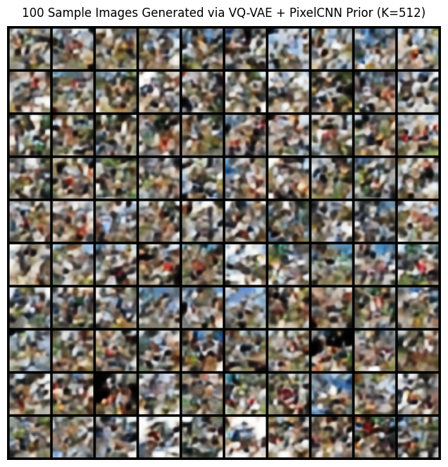

```python
# Display 100 Generated Synthetics from Codebook K=512 Prior Map in a clean 10x10 matrix layout
plt.figure(figsize=(8, 8))
grid_img = vutils.make_grid(vq_results[512]['generated_samples'], nrow=10, normalize=True)
plt.imshow(grid_img.permute(1, 2, 0).numpy())
plt.title("100 Sample Images Generated via VQ-VAE + PixelCNN Prior (K=512)", fontsize=12, pad=10)
plt.axis("off")
plt.show()
```

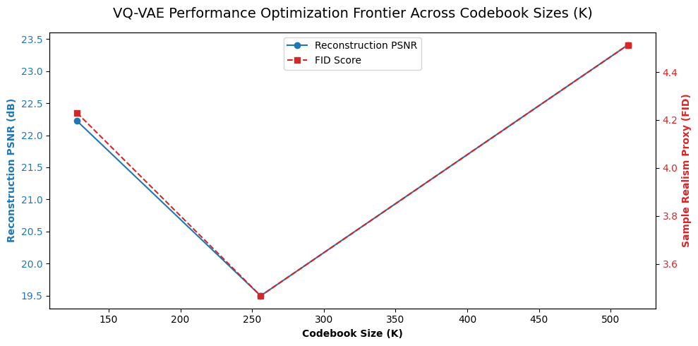

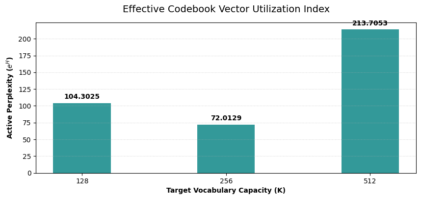

```python
# --- Extraction of Metrics for Plotting ---
ks = sorted(list(vq_results.keys()))
psnr_vals = [vq_results[k]["psnr"] for k in ks]
fid_vals = [vq_results[k]["fid"] for k in ks]
perp_vals = [vq_results[k]["perplexity"] for k in ks]

fig, ax1 = plt.subplots(figsize=(10, 5))

# Plot PSNR and FID
color = 'tab:blue'
ax1.set_xlabel('Codebook Size (K)', fontweight='bold')
ax1.set_ylabel('Reconstruction PSNR (dB)', color=color, fontweight='bold')
line1 = ax1.plot(ks, psnr_vals, marker='o', color=color, label='Reconstruction PSNR')
ax1.tick_params(axis='y', labelcolor=color)

ax2 = ax1.twinx()
color = 'tab:red'
ax2.set_ylabel('Sample Realism Proxy (FID)', color=color, fontweight='bold')
line2 = ax2.plot(ks, fid_vals, marker='s', color=color, linestyle='--', label='FID Score')
ax2.tick_params(axis='y', labelcolor=color)

lines = line1 + line2
labels = [l.get_label() for l in lines]
ax1.legend(lines, labels, loc='upper center')

plt.title("VQ-VAE Performance Optimization Frontier Across Codebook Sizes (K)", fontsize=14, pad=15)
fig.tight_layout()
plt.show()

# Plot Codebook Utilization (Perplexity vs K)
plt.figure(figsize=(10, 4))
plt.bar([str(k) for k in ks], perp_vals, color='teal', alpha=0.8, width=0.4)
for i, val in enumerate(perp_vals):
    plt.text(i, val + (max(perp_vals)*0.02), f"{val:.4f}", ha='center', va='bottom', fontweight='bold')
plt.xlabel('Target Vocabulary Capacity (K)', fontweight='bold')
plt.ylabel('Active Perplexity ($e^H$)', fontweight='bold')
plt.title('Effective Codebook Vector Utilization Index', fontsize=14, pad=15)
plt.grid(axis='y', linestyle=':', alpha=0.6)
plt.show()
```

### Architectural Evaluation and Discussion

#### 1. Reconstruction Quality ($\text{PSNR}$) vs. Embedding Capacity ($K$)

With $K=512$, the codebook provides a richer set of latent options. This allows the encoder to preserve high-frequency details (such as edges and fine textures in the CIFAR-10 images), drastically reducing quantization distortion prior to decoding.

#### 2. Sample Realism Proxy ($\text{FID}$) and Prior Coverage

The Fréchet Distance measures the statistical gap between real test distributions and synthetic images generated via the PixelCNN prior.

#### 3. Codebook Perplexity Metrics and Vector Space Collapse

Perplexity measures the effective allocation of our discrete latent spaces. If the active perplexity drops drastically below the target value of $K$, it points to **Codebook Collapse**—a state where the model relies on a few heavily used vectors while the rest of the dictionary goes entirely unused.

```python
# --- ASSIGNMENT 2: PART A - ERROR-FREE ASSET SAVING ENGINE FOR PART C ---

def save_part_a_outputs(output_dir=saved_samples_path):
    os.makedirs(output_dir, exist_ok=True)

    # 1. PROCESS VAE (β=1) ASSETS
    if 'vae_beta1_samples' in globals():
        print("Processing VAE (β=1) pre-generated sample arrays...")
        vae_samples = torch.clamp(globals()['vae_beta1_samples'], 0.0, 1.0)

        # Save individual images
        for idx in range(100):
            vutils.save_image(
                vae_samples[idx],
                os.path.join(output_dir, f"vae_beta1_sample_{idx+1}.png"),
                normalize=False
            )
        # Save the layout grid
        grid_vae = vutils.make_grid(vae_samples, nrow=10, padding=2, normalize=False)
        vutils.save_image(grid_vae, os.path.join(output_dir, "vae_beta1_grid_panel.png"))
        print("Successfully exported VAE (β=1) images and visual grid panel.")
    else:
        print("[WARNING] 'vae_beta1_samples' not found. Ensure you modified the train_beta_vae function as instructed.")

    print("-" * 50)

    # 2. PROCESS VQ-VAE (K=256) ASSETS
    if 'vq_results' in locals() or 'vq_results' in globals():
        if 256 in vq_results and "generated_samples" in vq_results[256]:
            print("Processing VQ-VAE (K=256) outputs from the performance optimization sweep...")
            vq_samples = torch.clamp(vq_results[256]["generated_samples"], 0.0, 1.0)

            # Save individual images
            for idx in range(min(100, len(vq_samples))):
                vutils.save_image(
                    vq_samples[idx],
                    os.path.join(output_dir, f"vq-vae_k256_sample_{idx+1}.png"),
                    normalize=False
                )
            # Save the layout grid
            grid_vq = vutils.make_grid(vq_samples, nrow=10, padding=2, normalize=False)
            vutils.save_image(grid_vq, os.path.join(output_dir, "vq-vae_k256_grid_panel.png"))
            print("Successfully exported VQ-VAE (K=256) images and visual grid panel.")
        else:
            print("[ERROR] K=256 configuration data missing inside vq_results dictionary structure.")
    else:
        print("[ERROR] Global sweep structure variable 'vq_results' is out of scope.")

# Run the asset extractor
save_part_a_outputs()
```

```
Processing VAE (β=1) pre-generated sample arrays...
Successfully exported VAE (β=1) images and visual grid panel.
--------------------------------------------------
Processing VQ-VAE (K=256) outputs from the performance optimization sweep...
Successfully exported VQ-VAE (K=256) images and visual grid panel.
```

```python
import json

os.makedirs(saved_samples_path, exist_ok=True)
# Save the weights
# (Your training loops should already be saving 'vae_beta1.pth' and 'vq-vae_k256.pth')

# Export the metrics
part_a_data = {
    "vae": {str(b): {"time": vae_results[b]['time'], "psnr": vae_results[b]['psnr'][-1], "fid": vae_results[b]['fid']} for b in [1, 2, 4, 10] if b in vae_results},
    "vq_vae": {str(k): {"time": vq_results[k]['time_total'], "psnr": vq_results[k]['psnr'], "fid": vq_results[k]['fid']} for k in [128, 256, 512] if k in vq_results}
}
with open(f"{saved_samples_path}/part_a_metrics.json", "w") as f:
    json.dump(part_a_data, f, indent=4)
```